# Chapter8 Summary: PART 1 - Questions 7 and 8

## Setup

```r
#setwd("/Users/anjali/Documents/university/Econ_5305/code_directory/Ch8_submission_full/")
rm(list = ls())
```

```r
library(openxlsx)
library(readxl)
library(ggplot2)
library(dynlm)
library(forecast)
library(urca)
library(lubridate)
library(TSstudio)
```

```r
# create a vector to store reference to all the models
model_names <- c()
model_aic <- c()
model_bic <- c()
model_cor <- c()
model_stationary <- c()
model_invertible <-c()
```

```r
store.function <- function(name = "None",this_model,DATA,stationary = TRUE,invertible = TRUE){
  model_names <<- append(model_names,name)
  model_aic <<- append(model_aic,AIC(this_model))
  model_bic <<- append(model_bic,BIC(this_model))
  this_cor <<- cor(fitted(this_model), DATA, use="pairwise.complete.obs")^2
  model_cor<<-append(model_cor,this_cor)
  model_stationary <<- append(model_stationary,stationary)
  model_invertible <<- append(model_invertible,invertible)
}
```

# Question 7

```r
# Import data set
FTSE_data <- read_excel("q7_stock_index.xlsx", sheet = 1)
SP500_data <- read_excel("q7_stock_index.xlsx", sheet = 2)
```

I joined the two data sets by date because the stock markets in the US and UK don’t always work on the same days as holidays are different.

```r
joined_df <- merge(FTSE_data, SP500_data, by.x = "Date",
             by.y = "Date", all.x = FALSE, all.y = FALSE)
tail(joined_df)
```

|  | Date | Open.x | High.x | Low.x | Close.x | Open.y | High.y | Low.y | Close.y |
| --- | --- | --- | --- | --- | --- | --- | --- | --- | --- |
| 5808 | 2023-04-24 | 7914.13 | 7927.11 | 7877.58 | 7912.20 | 4132.07 | 4142.41 | 4117.77 | 4137.04 |
| 5809 | 2023-04-25 | 7912.20 | 7912.52 | 7863.85 | 7891.13 | 4126.43 | 4126.43 | 4071.38 | 4071.63 |
| 5810 | 2023-04-26 | 7891.13 | 7893.95 | 7825.93 | 7852.64 | 4087.78 | 4089.67 | 4049.35 | 4055.99 |
| 5811 | 2023-04-27 | 7852.64 | 7865.73 | 7816.83 | 7831.58 | 4075.29 | 4138.24 | 4075.29 | 4135.35 |
| 5812 | 2023-04-28 | 7831.58 | 7870.57 | 7791.63 | 7870.57 | 4129.63 | 4170.06 | 4127.18 | 4169.48 |
| 5813 | 2023-05-01 | 7870.57 | 7870.57 | 7870.57 | 7870.57 | 4166.79 | 4186.92 | 4164.12 | 4167.87 |

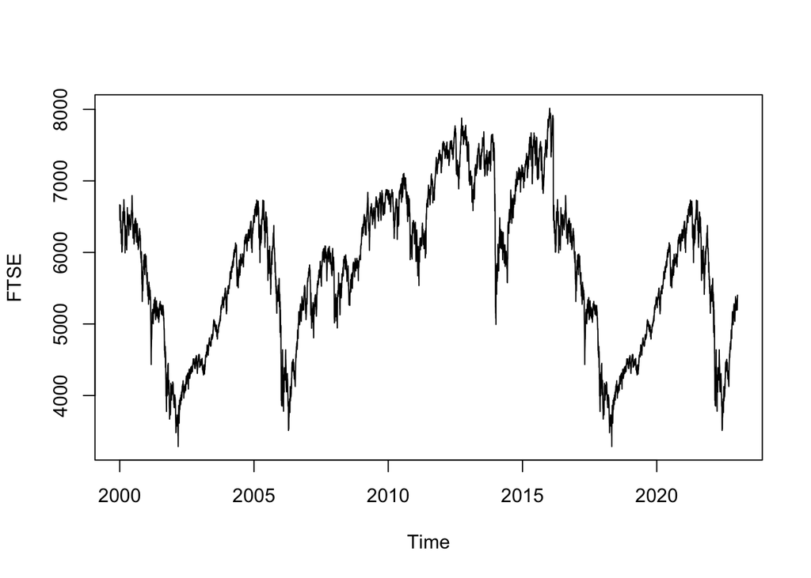

```r
FTSE<-ts(joined_df$Open.x, start=c(2000,1,4),frequency = 360, end =c (2023,5,1))
SP500<-ts(joined_df$Open.y, start=c(2000,1,4),frequency = 360, end =c (2023,5,1))
plot(FTSE)
```

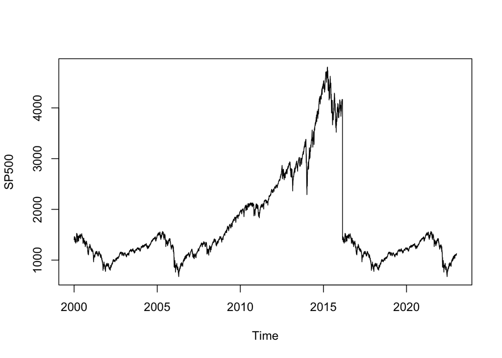

```r
plot(SP500)
```

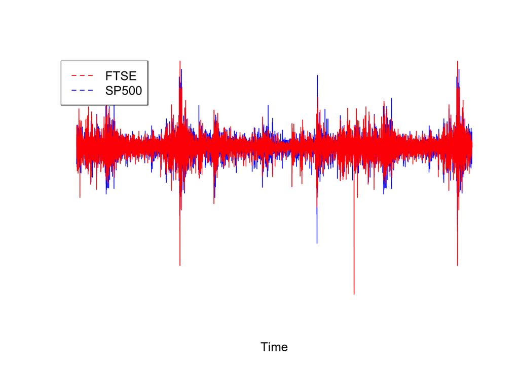

```r
# Daily returns
FTSE_return <- diff(log(FTSE))
SP500_return <- diff(log(SP500))
plot.ts(FTSE_return, axes=FALSE, ylab="", col="blue")
lines(SP500_return, col="red")
legend("topleft", legend=c("FTSE", "SP500"), lty=c(2,2,1), col=c( "red", "blue"))
```

```r
#Simple Linear Regression
model_1 <- lm(SP500_return ~ FTSE_return)
summary(model_1)
```

```
##
## Call:
## lm(formula = SP500_return ~ FTSE_return)
##
## Residuals:
##      Min       1Q   Median       3Q      Max
## -0.98446 -0.00513  0.00027  0.00549  0.08510
##
## Coefficients:
##               Estimate Std. Error t value Pr(>|t|)
## (Intercept) -9.688e-06  1.690e-04  -0.057    0.954
## FTSE_return  6.418e-01  1.357e-02  47.291   <2e-16 ***
## ---
## Signif. codes:  0 '***' 0.001 '**' 0.01 '*' 0.05 '.' 0.1 ' ' 1
##
## Residual standard error: 0.01538 on 8282 degrees of freedom
## Multiple R-squared:  0.2126, Adjusted R-squared:  0.2125
## F-statistic:  2236 on 1 and 8282 DF,  p-value: < 2.2e-16
```

```r
#Correlation Matrix
df <- data.frame(SP500_return, FTSE_return)
df <- na.omit(df)
cor_matrix <- cor(df)
print(cor_matrix)
```

```
##              SP500_return FTSE_return
## SP500_return    1.0000000   0.4611057
## FTSE_return     0.4611057   1.0000000
```

There is a correlation of 0.46 but again this not very high > 0.75. **Note** For this question we can use different logic to try and answer the question. For instance, the benchmark regression could use just use one SP500, in some order of AR or ARMA process. One can also consider to add the current ( you do know at the time of current day of trading in New York ) and a few lags of FTSE.

#### Conclusion

Based on the simple linear regression and the correlation matrix, there is a positive linear relationship between the two variables but it’s not too strong. FTSE returns can predict the SP500 returns to a certain degree.

# Question 8

```r
FOREX <- ts( data =  read_excel("q8_exchangerate.xlsx")[ , c( "EXCHANGE_RATE" )]  ,
               start = c(1999, 1, 1 ) ,
               end = c( 2023 , 4, 1 ) ,
               frequency = 12
                 )
```

```r
cat("US - Euro Exchange Rate")
```

```
## US - Euro Exchange Rate
```

```r
summary(FOREX)
```

```
##  EXCHANGE_RATE
##  Min.   :0.8525
##  1st Qu.:1.0888
##  Median :1.1829
##  Mean   :1.1914
##  3rd Qu.:1.3120
##  Max.   :1.5759
```

```r
cat("Standard deviation: ", sd(FOREX))
```

```
## Standard deviation:  0.1580108
```

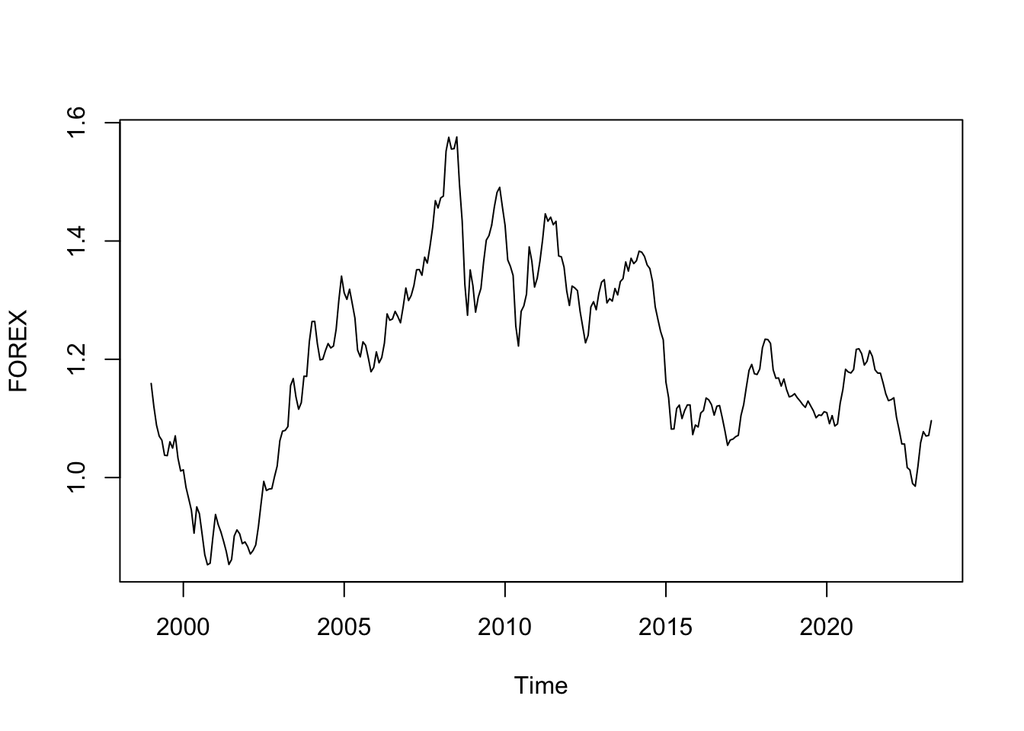

```r
ts.plot(FOREX)
```

```r
ur.df(FOREX,type="drift",lags=1)
```

```
##
## ###############################################################
## # Augmented Dickey-Fuller Test Unit Root / Cointegration Test #
## ###############################################################
##
## The value of the test statistic is: -1.9848 1.9698
```

**Unit Root is present:** There is some stochastic trend in the series so we need to consider looking at the 1st difference.

```r
dFOREX <- diff(FOREX)
ur.df(dFOREX,type="drift",lags=0)
```

```
##
## ###############################################################
## # Augmented Dickey-Fuller Test Unit Root / Cointegration Test #
## ###############################################################
##
## The value of the test statistic is: -12.4787 77.8697
```

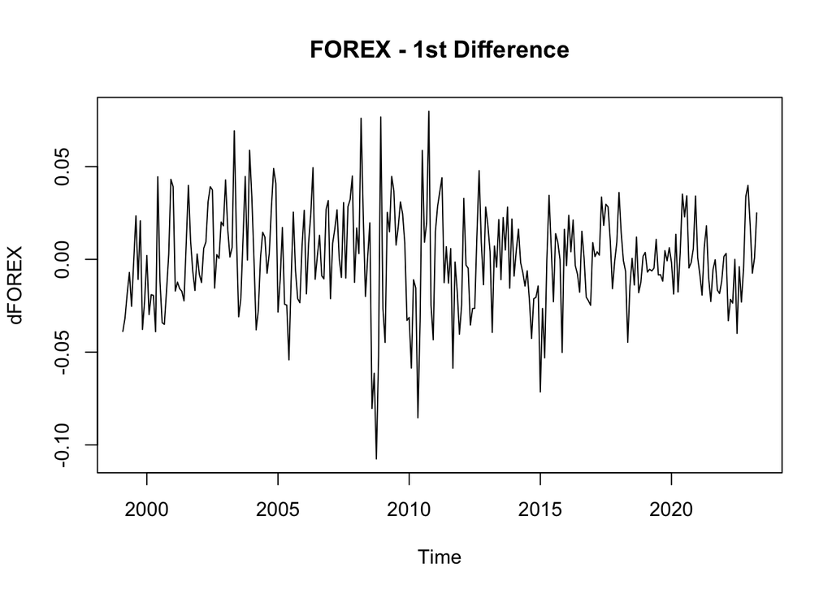

```r
ts.plot(dFOREX , main ="FOREX - 1st Difference")
```

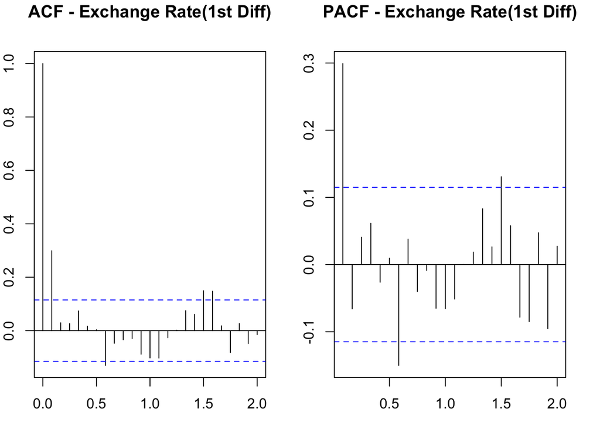

```r
par(mfrow=c(1,2) , mar = c(3, 2, 3, 2))
acf(dFOREX, main = "ACF - Exchange Rate(1st Diff)")
pacf(dFOREX, main = "PACF - Exchange Rate(1st Diff)")
```

Looking at the ACF a(nd PACF we see that there is 1 spike in the ACF and sharp fall in correlation which can indicate MA(1) model. Looking at PACF we could consider a AR(1) model. ARMA(1,1) and AR(1,2) (Aya’s model)

```r
# Split the data into training and testing sets
split_forex <- ts_split(ts.obj = dFOREX, sample.out = 12)
train_forex <- split_forex$train
test_forex <- split_forex$test
```

```r
auto_arima <- auto.arima(train_forex, seasonal = TRUE)
auto_arima
```

```
## Series: train_forex
## ARIMA(0,0,1) with zero mean
##
## Coefficients:
##          ma1
##       0.3105
## s.e.  0.0545
##
## sigma^2 = 0.0006666:  log likelihood = 624.77
## AIC=-1245.53   AICc=-1245.49   BIC=-1238.27
```

```r
cat("\n -----\n")
ma1 <- arima(train_forex, order=c(0, 0, 1))
ma1
```

```
##
## Call:
## arima(x = train_forex, order = c(0, 0, 1))
##
## Coefficients:
##          ma1  intercept
##       0.3104     -3e-04
## s.e.  0.0545      2e-03
##
## sigma^2 estimated as 0.0006642:  log likelihood = 624.78,  aic = -1243.56
```

```r
ar1 <- arima(train_forex, order=c(1, 0, 0))
ar1
```

```
##
## Call:
## arima(x = train_forex, order = c(1, 0, 0))
##
## Coefficients:
##          ar1  intercept
##       0.2974    -0.0004
## s.e.  0.0573     0.0022
##
## sigma^2 estimated as 0.0006675:  log likelihood = 624.09,  aic = -1242.17
```

```r
ar1ma1 <- arima(train_forex, order=c(1, 0, 1))
ar1ma1
```

```
##
## Call:
## arima(x = train_forex, order = c(1, 0, 1))
##
## Coefficients:
##          ar1     ma1  intercept
##       0.0786  0.2415    -0.0003
## s.e.  0.1761  0.1695     0.0021
##
## sigma^2 estimated as 0.0006637:  log likelihood = 624.88,  aic = -1241.76
```

```r
ar1ma2 <- arima(train_forex, order=c(1, 0, 2))
ar1ma2
```

```
##
## Call:
## arima(x = train_forex, order = c(1, 0, 2))
##
## Coefficients:
##          ar1      ma1      ma2  intercept
##       0.6056  -0.2854  -0.1610    -0.0004
## s.e.  0.5418   0.5494   0.1879     0.0022
##
## sigma^2 estimated as 0.0006634:  log likelihood = 624.93,  aic = -1239.87
```

```r
# plot(auto_arima, main ="Auto Arima: Inverse Roots")
# plot(ma1, main ="ARMA(0,0,1): Inverse Roots")
# plot(ar1, main ="ARMA(1,0,0): Inverse Roots")
# plot(ar1ma1, main ="ARMA(1,0,1): Inverse Roots")
# plot(ar1ma2, main ="ARMA(1,0,2): Inverse Roots")

store.function("Auto Arima",auto_arima,train_forex,TRUE,TRUE)
store.function("ARMA(0,0,1)",ma1,train_forex,TRUE,TRUE)
store.function("ARMA(1,0,0)",ar1,train_forex,TRUE,TRUE)
store.function("ARMA(1,0,1)",ar1ma1,train_forex,TRUE,TRUE)
store.function("ARMA(1,0,2)",ar1ma2,train_forex,TRUE,TRUE)
```

```r
# combine everything into 1 large data frame
all_models <- data.frame(model_names, model_aic, model_bic, model_cor, model_stationary, model_invertible)
all_models
```

| model_names | model_aic | model_bic | model_cor | model_stationary | model_invertible |
| --- | --- | --- | --- | --- | --- |
| Auto Arima | -1245.531 | -1238.269 | 0.09285706 | TRUE | TRUE |
| ARMA(0,0,1) | -1243.558 | -1232.664 | 0.09287989 | TRUE | TRUE |
| ARMA(1,0,0) | -1242.175 | -1231.281 | 0.08825780 | TRUE | TRUE |
| ARMA(1,0,1) | -1241.762 | -1227.237 | 0.09346571 | TRUE | TRUE |
| ARMA(1,0,2) | -1239.868 | -1221.712 | 0.09381504 | TRUE | TRUE |

#### Conclusion

All the models have extremely low R^2. The Auto Arima model selects MA(1) model for modelling the process. The ACF and PACF are very close to noise. Constructing a 12 month forecast for this data is not possible. Only a short term model is possible. Most stock market data tends to be very close to white noise and we see the same pattern for the exchange rate as well.From the plot below we can see that only 1 prediction is possible for 1 month after this it reverts to unconditional mean and variance.

```r
# Forecast using MA(1) model
forecast <- forecast(ma1, h = 12)
forecast
```

```
##          Point Forecast       Lo 80      Hi 80       Lo 95      Hi 95
## May 2022  -0.0037007347 -0.03672873 0.02932726 -0.05421270 0.04681123
## Jun 2022  -0.0003336539 -0.03491583 0.03424853 -0.05322253 0.05255523
## Jul 2022  -0.0003336539 -0.03491583 0.03424853 -0.05322253 0.05255523
## Aug 2022  -0.0003336539 -0.03491583 0.03424853 -0.05322253 0.05255523
## Sep 2022  -0.0003336539 -0.03491583 0.03424853 -0.05322253 0.05255523
## Oct 2022  -0.0003336539 -0.03491583 0.03424853 -0.05322253 0.05255523
## Nov 2022  -0.0003336539 -0.03491583 0.03424853 -0.05322253 0.05255523
## Dec 2022  -0.0003336539 -0.03491583 0.03424853 -0.05322253 0.05255523
## Jan 2023  -0.0003336539 -0.03491583 0.03424853 -0.05322253 0.05255523
## Feb 2023  -0.0003336539 -0.03491583 0.03424853 -0.05322253 0.05255523
## Mar 2023  -0.0003336539 -0.03491583 0.03424853 -0.05322253 0.05255523
## Apr 2023  -0.0003336539 -0.03491583 0.03424853 -0.05322253 0.05255523
```

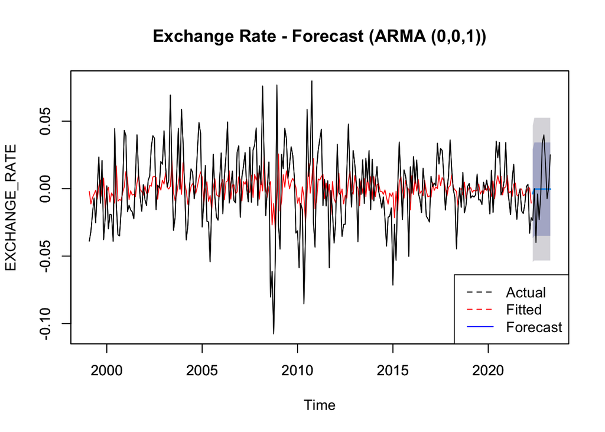

```r
plot(forecast, main = "Exchange Rate - Forecast (ARMA (0,0,1))")
lines(fitted(ma1),col="red")
par(new=TRUE)
plot(dFOREX) #plot the original series
legend("bottomright", legend=c("Actual", "Fitted","Forecast"), lty=c(2,2,1), col=c( "black","red", "blue"))
```